# Analiza asupra Autovehiculelor Electrice

Kutkut Sami, Luca Andreea Giorgiana, Mertic Yulyssa Nicoleta Ioana

22/01/2022

## I. Prezentarea Domeniului

Prezenta analiză se concentrează pe observarea caracteristicilor autovehiculelor electrice dintr-un set de date preluat de pe site-ul Kaggel: https://www.kaggle.com/code/prateekmaj21/electric-cars-data-analysis/data  
În acest sens se dorește observarea diferențelor, asemănărilor si performanțelor setului înregistrat din punct de vedere al capacității bateriei, consumului de electricitate, distanța ce poate fi parcursă, viteza, preț si desigur a altor caracteristici.

## III. Literatură de specialitate

Vehiculele electrice (EV) reprezintă o tehnologie promițătoare pentru realizarea unui sector de transport durabil în viitor, datorită emisiilor de carbon foarte scăzute până la zero, zgomotului redus, eficienței ridicate și flexibilității în funcționarea și integrarea în rețea. Acest capitol include o prezentare generală a tehnologiilor vehiculelor electrice, precum și a sistemelor asociate de stocare a energiei și a mecanismelor de încărcare. Sunt prezentate diferite tipuri de vehicule cu propulsie electrică.

- " Nanaki, Evanthia A. (2021). Electric Vehicles for Smart Cities || Electric vehicles. , (), 13–49. doi:10.1016/B978-0-12-815801-2.00006-X " https://www.sciencedirect.com/science/article/pii/B978012815801200006X
- "Kittner, Noah (2020). *Technological Learning in the Transition to a Low-Carbon Energy System || Electric vehicles. , (), 145–163.* doi:10.1016/B978-0-12-818762-3.00009-1 "  
  https://www.sciencedirect.com/science/article/pii/B9780128187623000091

## IV. Baza de date

```
## # A tibble: 164 × 9
##    Name          Useab…¹ Accel…² TopSp…³ Range…⁴ Effic…⁵ FastC…⁶ Numbe…⁷ Price…⁸
##    <chr>           <dbl>   <dbl>   <dbl>   <dbl>   <dbl>   <dbl>   <dbl>   <dbl>
##  1 Opel Ampera-e    58       7.3     150     335     173     210       5   42990
##  2 Nissan Leaf      36       7.9     144     220     164     230       5   29990
##  3 Porsche Tayc…    83.7     2.8     260     390     215     860       4  186336
##  4 Nissan e-NV2…    36      14       123     165     218     170       7   43433
##  5 Volkswagen I…    45       8.9     160     275     164     260       5   31960
##  6 BMW iX3          74       6.8     180     385     192     520       5   66300
##  7 Nissan Leaf …    56       7.3     157     325     172     390       5   38350
##  8 BMW i3 120 Ah    37.9     7.3     150     235     161     270       4   39000
##  9 Mercedes EQA…    66.5     8.9     160     355     187     420       5   47541
## 10 DS 3 Crossba…    45       8.7     150     250     180     330       5   30040
## # … with 154 more rows, and abbreviated variable names
## #   ¹`Useable Capacity: kWh`, ²`Acceleration(sec)`, ³`TopSpeed(km/h)`,
## #   ⁴`Range(km)`, ⁵`Efficiency(Wh/km)`, ⁶`FastChargeSpeed(km/h)`,
## #   ⁷NumberofSeats, ⁸PriceinEuro
```

- **Useable Capacity: kWh**  
  Capacitate utilizabilă sau „kilowați-oră (kWh) disponibile” reprezintă de obicei 95%-99% din capacitatea totală disponibilă. De exemplu, o baterie care poate ține fizic un total de 65 kWh poate pune la dispoziție numai 62 kWh pentru mașină.
- **Acceleration(sec)**  
  Acest indicator se referă la timpul necesar pentru a ajunge la 100 km/h. Timpul este exprimat în secunde.
- **TopSpeed(km/h)**  
  Viteza maximă la care poate ajunge mașina.
- **Range(km)**  
  Cât poate parcurge mașina cu un plin al bateriei.
- **Efficiency(Wh/km)** Eficiența este măsurată în wați-oră pe km, sau mai frecvent scrisă ca wh/km. Aceasta înseamnă că pentru fiecare kilometru parcurs, vehiculul dumneavoastră electric va consuma, în medie, xx wați oră din acumulator.
- **FastChargeSpeed(km/h)**  
  Măsoară câți km poate parcurge mașina cu o oră de încărcare în modul FastCharge.
- **NumberofSeats**  
  Numărul de locuri disponibil în mașină.
- **PriceinEuro**  
  Prețul în euro.

## V. Analiza Descriptivă

Pentru a analiza setul de date, am verificat existenta outlierilor. In acest sens, boxploturile de mai jos au evidentiat ca exista un numar mic de outlieri, neseminifcativi pentru atingerea obiectiviului analize.

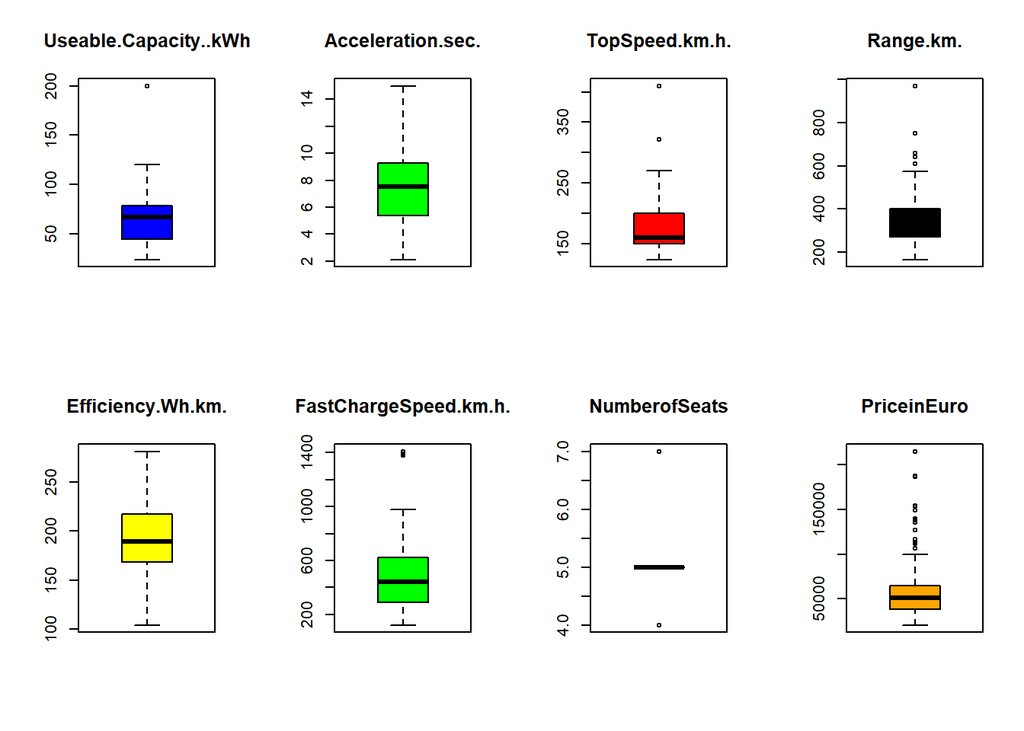

```r
cars1<-data.frame(Cars[,-1])
#cars1
par(mfrow=c(2,4))
boxplot(cars1$Useable.Capacity..kWh, main="Useable.Capacity..kWh", col="blue")#Are un(1) outlier
boxplot(cars1$Acceleration.sec., main="Acceleration.sec.", col="green") #Nu are outlieri
boxplot(cars1$TopSpeed.km.h., main="TopSpeed.km.h.", col="red") #Are 2 outlieri
boxplot(cars1$Range.km., main="Range.km.", col="black") #Are 5 outlieri
boxplot(cars1$Efficiency.Wh.km., main="Efficiency.Wh.km.", col="yellow") #Nu are outlieri
boxplot(cars1$FastChargeSpeed.km.h., main="FastChargeSpeed.km.h.", col="green") #Are 3-4outlieri
boxplot(cars1$NumberofSeats, main="NumberofSeats", col="pink") #Are 2 outlieri
boxplot(cars1$PriceinEuro, main="PriceinEuro", col="orange") #Are multi outlieri
```

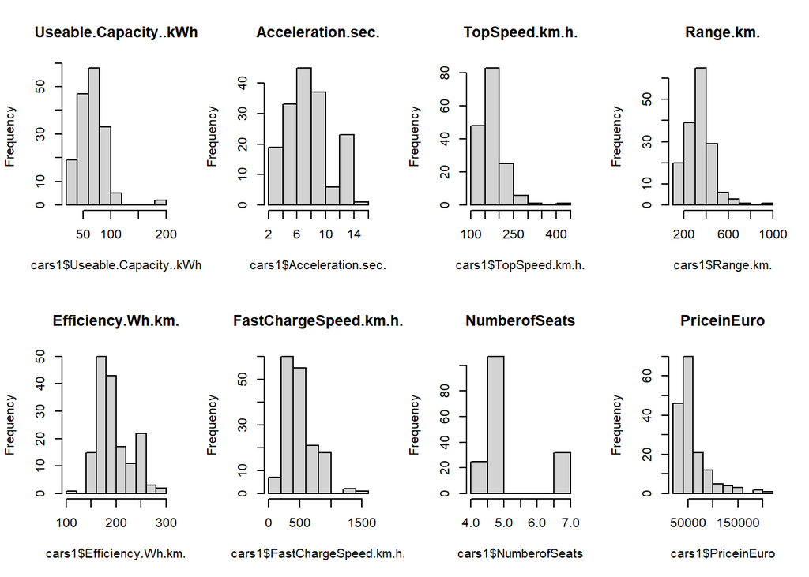

```r
par(mfrow=c(2,4))
hist(cars1$Useable.Capacity..kWh, main="Useable.Capacity..kWh")
hist(cars1$Acceleration.sec., main="Acceleration.sec.")
hist(cars1$TopSpeed.km.h., main="TopSpeed.km.h.")
hist(cars1$Range.km., main="Range.km.")
hist(cars1$Efficiency.Wh.km., main="Efficiency.Wh.km.")
hist(cars1$FastChargeSpeed.km.h., main="FastChargeSpeed.km.h.")
hist(cars1$NumberofSeats, main="NumberofSeats")
hist(cars1$PriceinEuro, main="PriceinEuro")
```

```r
library(psych)
describe(cars1)
```

```
##                       vars   n     mean       sd   median  trimmed      mad
## Useable.Capacity..kWh    1 164    66.73    24.40    67.25    65.36    24.39
## Acceleration.sec.        2 164     7.67     2.97     7.50     7.56     2.97
## TopSpeed.km.h.           3 164   177.74    42.66   160.00   172.55    37.06
## Range.km.                4 164   344.09   116.26   340.00   335.95   103.78
## Efficiency.Wh.km.        5 164   195.35    33.20   189.00   193.09    31.13
## FastChargeSpeed.km.h.    6 164   486.65   246.97   440.00   460.68   229.80
## NumberofSeats            7 164     5.24     0.94     5.00     5.17     0.00
## PriceinEuro              8 164 59644.97 32574.04 50890.00 53645.63 19110.71
##                           min    max    range skew kurtosis      se
## Useable.Capacity..kWh    23.8    200    176.2 1.89     8.83    1.91
## Acceleration.sec.         2.1     15     12.9 0.34    -0.63    0.23
## TopSpeed.km.h.          123.0    410    287.0 1.61     4.62    3.33
## Range.km.               165.0    970    805.0 1.35     4.79    9.08
## Efficiency.Wh.km.       104.0    281    177.0 0.57    -0.33    2.59
## FastChargeSpeed.km.h.   120.0   1410   1290.0 1.18     1.58   19.28
## NumberofSeats             4.0      7      3.0 0.93    -0.12    0.07
## PriceinEuro           20490.0 215000 194510.0 2.15     5.35 2543.61
```

Observăm histogramele variabilelor, putem spune că predomină distribuțiile **leptocurtice,** însă aplicând funcția “describe” obtinem valorile pentru skewness si kurtosis care ne arată precis ce tipuri de distribuție avem. Dacă coeficientul de boltire este mai mic decât 3 (<3) avem distribuții platicurtice, în caz contrar leptocurtice ( >3).  
În cazul nostru, distribuții platicurtice avem pentru variabilele: Acceleration(sec), Efficiency.Wh.km., FastCharge, NumberofSeats.  
Indicele de asimetrie pozitiv, ne arată că majoritatea datelor sunt distibuite spre stânga, ceea ce înseamna că predomină valorile mici.

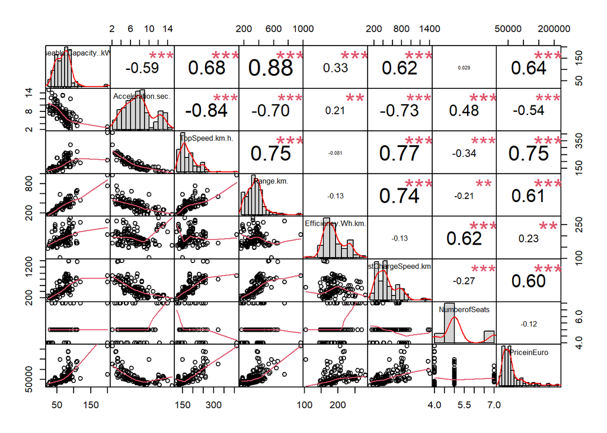

```r
cars2<-cars1[,1:8]
#cars2
library(PerformanceAnalytics)
library(xts)
library(zoo)
windows()
suppressWarnings(chart.Correlation(cars1, histogram=T, pch=19))
```

Prin pachetul PerformanceAnalytics am generat graficul din figura de mai sus.  
Pe diagonala principală putem observa histogramele pentru fiecare variabilă. Deasupra diagonalei principale regăsim valoarea corelațiilor si totodată nivelul de semnificație al indicatorilor. Fiecare nivel de semnificație are asociat un simbol format din una sau mai multe steluțe. În cazul setului nostru de date, predomină simbolul cu trei stelute, ceea ce înseamnă o valoare a lui P-value de 0.001.  
Sub diagonala principală regăsim legăturile dintre variabilele reprezentate prin grafice de tip plot. Cu ajutorul lor putem analiza legătura dintre fiecare două componente și modul în care sunt distribuite datele de-a lungul bisectoarei care ne dă sensul legăturii.

Spre exemplu, unul dintre ploturile importante regăsite în acest grafic este cel ce face referire la corelația dintre variabilele Useable Capacity: kWh și Range(km), unde putem observa un coeficient de corelație de 0.88, fiind o corelație directă și puternică deoarce tinde spre 1.

## VI. Analiza Componentelor Principale

Pentru a aplica analiza componentelor principale am standardizat datele si am analizat matricea de corelatie pentru a vedea legaturile dintre variabile. Pentru extragerea componentelor principale am utilizat functia princomp pentru datele standardizate si am obtinut urmatorul output:

```r
cars2<-data.frame(cars1[,1:8])
#View(cars2)
date_st<-scale(cars2,scale=T)
#date_st
PCA<-princomp(date_st,cor = T)
sdev<-PCA$sdev
valp<-sdev*sdev
procent_info<-valp*100/ 8
procent_cumulat<-cumsum(procent_info)
X<-round(data.frame(sdev,valp,procent_info,procent_cumulat),3)
X
```

```
##         sdev  valp procent_info procent_cumulat
## Comp.1 2.142 4.587       57.333          57.333
## Comp.2 1.354 1.834       22.921          80.254
## Comp.3 0.742 0.551        6.886          87.140
## Comp.4 0.609 0.371        4.636          91.776
## Comp.5 0.568 0.323        4.038          95.814
## Comp.6 0.473 0.224        2.803          98.617
## Comp.7 0.320 0.102        1.276          99.893
## Comp.8 0.092 0.009        0.107         100.000
```

În ceea ce privește prima componentă, abaterea standard a acesteia are cea mai mare valoare dintre cele opt componente identificate, de 2.142. Procentul de informație preluat de aceasta este de 57.333%. De asemenea, în ceea ce privește procentul cumulat de primele două componente este de 80.254%

Pentru a determina numărul de componente principale am urmat 3 criterii de determinare:

- **Criteriul lui Kaiser**, conform căruia se iau în calcul doar numărul de componente principale care au varianta mai mare sau egală cu 1.
- **Criteriul procentului de acoperire** prin care numărul optim de componente este cel care are un procent cumulat mai mare de 80%.
- **Criteriul pantei** prin care se realizează un grafic cu o tăietura după o dreaptă paralelă cu ordonata, astfel încat la dreaptă tăieturii să ramană o porțiune de grafic unde panta este aproape zero.

**Conform celor trei criterii, în analiza trebuie urmărite două componente principale.**

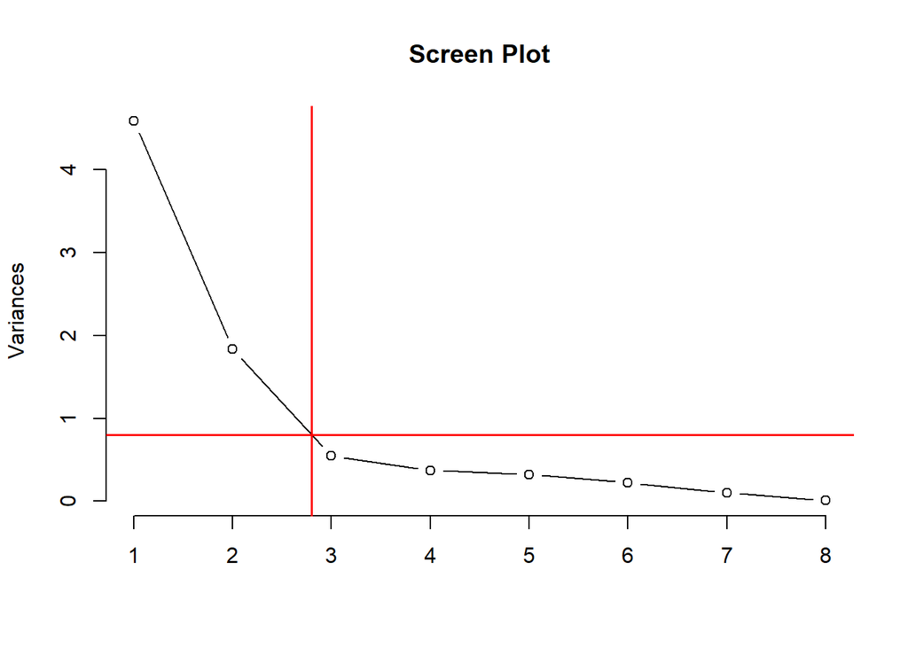

```r
scree_plot<-prcomp(date_st)
plot(scree_plot, type="l", main="Screen Plot")
abline(v=2.8, lwd=1.5, col="red")
abline(h=0.8, lwd=1.5, col="red")
```

Vom denumi prima componenta **Performanță** – aceasta fiind formata din variabilele Useable Capacity, Acceleration, TopSpeed, Range, FastCharge, PriceinEuro.  
Cea de-a doua componenta se va numi **Diverse**– aceasta fiind formata din variabilele Efficiency și NumberOfSeats.

```r
c<-PCA$scores[,1:2]

round(cor(c),3)
```

```
##        Comp.1 Comp.2
## Comp.1      1      0
## Comp.2      0      1
```

```r
mat_factor<-cor(date_st,c)
round(mat_factor,3)
```

```
##                       Comp.1 Comp.2
## Useable.Capacity..kWh  0.819  0.436
## Acceleration.sec.     -0.873  0.235
## TopSpeed.km.h.         0.930 -0.037
## Range.km.              0.900  0.058
## Efficiency.Wh.km.     -0.072  0.916
## FastChargeSpeed.km.h.  0.864 -0.049
## NumberofSeats         -0.354  0.810
## PriceinEuro            0.775  0.292
```

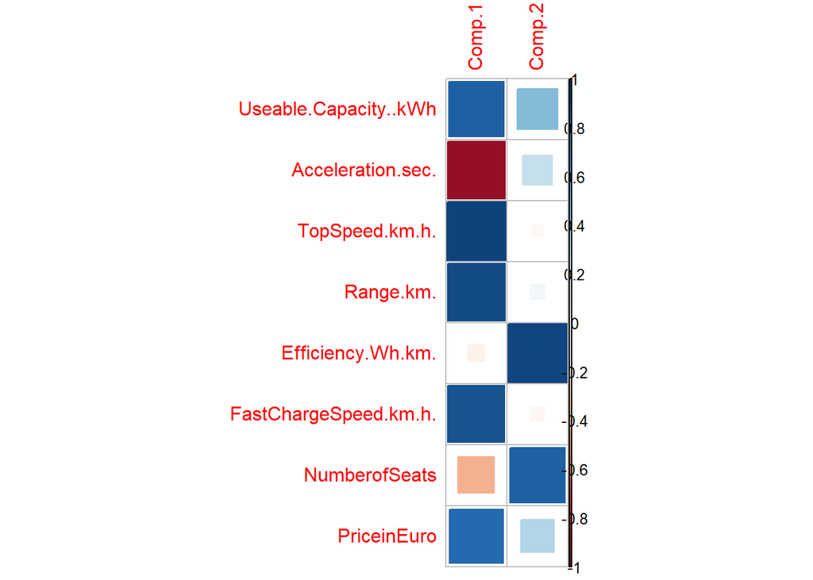

```r
library(corrplot)
corrplot(mat_factor,method="square")
```

```r
library(factoextra)
```

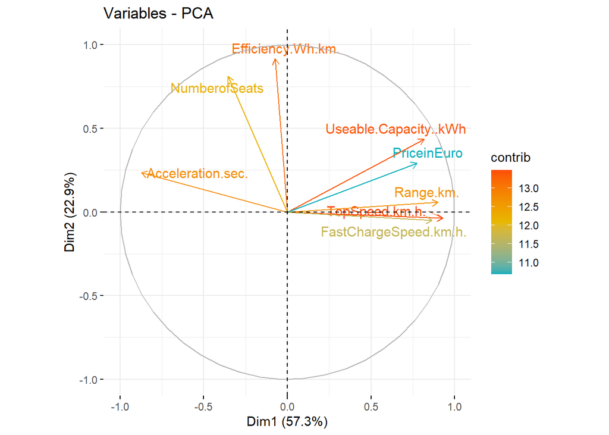

```r
library(ggplot2)

fviz_pca_var(PCA, col.var="contrib",
             gradient.cols = c("#00AFBB", "#E7B800", "#FC4E07"),
             repel = TRUE # Avoid text overlapping
)
```

## VII. Arbori de clasificare

```r
set.seed(42)
n     <- nrow(Cars)
train <- Cars[sample(n, n/4), ]

library(dplyr)
train <- sample_n(Cars, n / 4)

#View(train)


library(party)
```

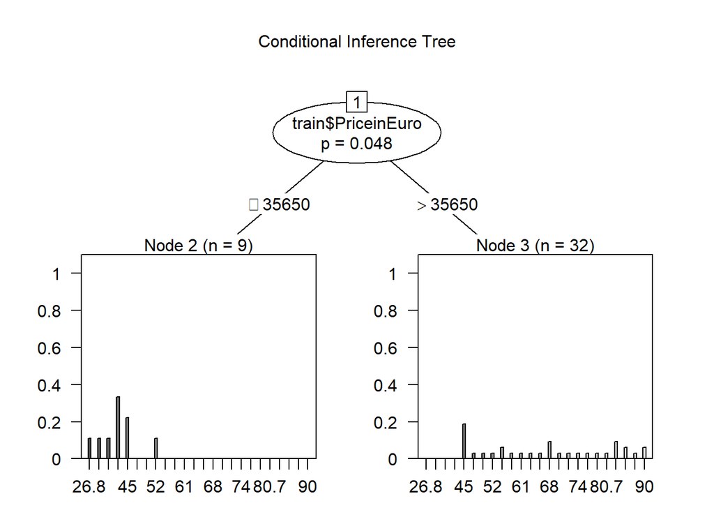

```r
ct <- ctree(factor(train$`Useable Capacity: kWh`) ~ train$PriceinEuro, data = train, controls = ctree_control(minsplit = 3))
plot(ct, main = "Conditional Inference Tree")
```

## VIII. Concluzii

În concluzie, în urma analizelor realizate pentru setul de date ales, s-au conturat pricipalele caracteristici ale automobilelor electrice și s-a determinat eficiența mașinilor. În acest sens am determinat 2 componente principale, acestea au fost denumite componenta “Performanță”, fiind formata din variabilele Useable Capacity, Acceleration, TopSpeed, Range, FastCharge, PriceinEuro și componenta “Diverse”, formată din variabilele Efficiency și NumberOfSeats.